# Week 2 work

Arin Vansomphone

2023-07-22

**Goal: to see how the extension of parsnip was set up and mimic the same framework to build up the extensions for `lme4`.**

# Source 1: Multilevelmod

```r
library(tidymodels)
library(multilevelmod)
```

Data: effects of sleep deprivation on reaction time

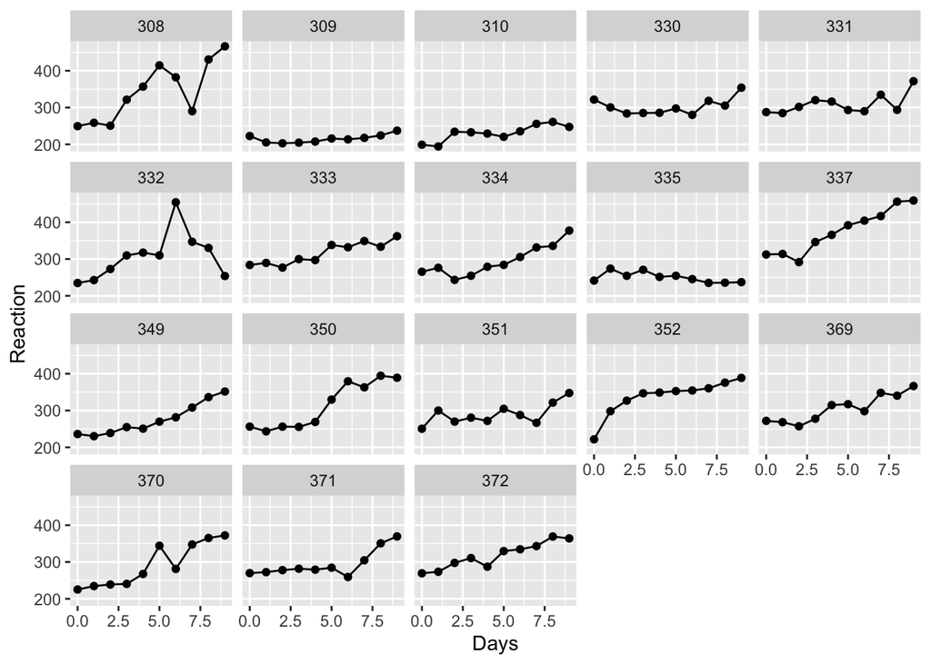

```r
data(sleepstudy, package = "lme4")

sleepstudy %>%
  ggplot(aes(x = Days, y = Reaction)) +
  geom_point() +
  geom_line() +
  facet_wrap(~ Subject)
```

```r
# create new data frame for hypothetical subject for prediction
new_subject <- tibble(
  Days = 0:9,
  Subject = "one"
)
```

### Generalized estimator equations (GEE)

GEE estimates a correlation/covariance matrix that is not diagonal

```r
# creating correlation structure
gee_spec <-
  linear_reg() %>%
  set_engine("gee", corstr = "exchangeable")

gee_fit <-
  gee_spec %>%
  fit(Reaction ~ Days + id_var(Subject), data = sleepstudy)
```

```
## Beginning Cgee S-function, @(#) geeformula.q 4.13 98/01/27
```

```
## running glm to get initial regression estimate
```

```r
gee_fit
```

```
## parsnip model object
##
##
##  GEE:  GENERALIZED LINEAR MODELS FOR DEPENDENT DATA
##  gee S-function, version 4.13 modified 98/01/27 (1998)
##
## Model:
##  Link:                      Identity
##  Variance to Mean Relation: Gaussian
##  Correlation Structure:     Exchangeable
##
## Call:
## gee::gee(formula = Reaction ~ Days, id = data$Subject, data = data,
##     family = gaussian, corstr = "exchangeable")
##
## Number of observations :  180
##
## Maximum cluster size   :  10
##
##
## Coefficients:
## (Intercept)        Days
##   251.40510    10.46729
##
## Estimated Scale Parameter:  2276.694
## Number of Iterations:  1
##
## Working Correlation[1:4,1:4]
##           [,1]      [,2]      [,3]      [,4]
## [1,] 1.0000000 0.5710385 0.5710385 0.5710385
## [2,] 0.5710385 1.0000000 0.5710385 0.5710385
## [3,] 0.5710385 0.5710385 1.0000000 0.5710385
## [4,] 0.5710385 0.5710385 0.5710385 1.0000000
##
##
## Returned Error Value:
## [1] 0
```

```r
# running prediction
predict(gee_fit, new_subject %>% select(Days)) %>%
  bind_cols(new_subject)
```

```
## # A tibble: 10 × 3
##    .pred  Days Subject
##    <dbl> <int> <chr>
##  1  251.     0 one
##  2  262.     1 one
##  3  272.     2 one
##  4  283.     3 one
##  5  293.     4 one
##  6  304.     5 one
##  7  314.     6 one
##  8  325.     7 one
##  9  335.     8 one
## 10  346.     9 one
```

### Generalized least squares

```r
library(nlme)
gls_spec <-
  linear_reg() %>%
  set_engine("gls", correlation = corCompSymm(form = ~ 1 | Subject))

gls_fit <-
  gls_spec %>%
  fit(Reaction ~ Days, data = sleepstudy)

gls_fit
```

```
## parsnip model object
##
## Generalized least squares fit by REML
##   Model: Reaction ~ Days
##   Data: data
##   Log-restricted-likelihood: -893.2325
##
## Coefficients:
## (Intercept)        Days
##   251.40510    10.46729
##
## Correlation Structure: Compound symmetry
##  Formula: ~1 | Subject
##  Parameter estimate(s):
##       Rho
## 0.5893103
## Degrees of freedom: 180 total; 178 residual
## Residual standard error: 48.3595
```

```r
# running predictions
predict(gls_fit, new_subject %>% select(Days)) %>%
  bind_cols(new_subject)
```

```
## # A tibble: 10 × 3
##    .pred  Days Subject
##    <dbl> <int> <chr>
##  1  251.     0 one
##  2  262.     1 one
##  3  272.     2 one
##  4  283.     3 one
##  5  293.     4 one
##  6  304.     5 one
##  7  314.     6 one
##  8  325.     7 one
##  9  335.     8 one
## 10  346.     9 one
```

### Linear mixed effects model (lme)

```r
lme_spec <-
  linear_reg() %>%
  set_engine("lme", random = ~ 1 | Subject)

lme_fit <-
  lme_spec %>%
  fit(Reaction ~ Days, data = sleepstudy)

lme_fit
```

```
## parsnip model object
##
## Linear mixed-effects model fit by REML
##   Data: data
##   Log-restricted-likelihood: -893.2325
##   Fixed: Reaction ~ Days
## (Intercept)        Days
##   251.40510    10.46729
##
## Random effects:
##  Formula: ~1 | Subject
##         (Intercept) Residual
## StdDev:    37.12383 30.99123
##
## Number of Observations: 180
## Number of Groups: 18
```

```r
# running predictions
predict(lme_fit, new_subject) %>%
  bind_cols(new_subject)
```

```
## # A tibble: 10 × 3
##    .pred  Days Subject
##    <dbl> <int> <chr>
##  1  251.     0 one
##  2  262.     1 one
##  3  272.     2 one
##  4  283.     3 one
##  5  293.     4 one
##  6  304.     5 one
##  7  314.     6 one
##  8  325.     7 one
##  9  335.     8 one
## 10  346.     9 one
```

```r
# similar prediction command as a training set point
predict(lme_fit, sleepstudy %>% filter(Subject == "308"))
```

```
## # A tibble: 10 × 1
##    .pred
##    <dbl>
##  1  251.
##  2  262.
##  3  272.
##  4  283.
##  5  293.
##  6  304.
##  7  314.
##  8  325.
##  9  335.
## 10  346.
```

### Models using lmer, glmer, and stan_glmer

- `"lmer"`, `"glmer"`, and `"stan_glmer"` all use the same formula syntax for fitting

```r
# using lmer as an example
lmer_spec <-
  linear_reg() %>%
  set_engine("lmer")

lmer_fit <-
  lmer_spec %>%
  fit(Reaction ~ Days + (1|Subject), data = sleepstudy)

lmer_fit
```

```
## parsnip model object
##
## Linear mixed model fit by REML ['lmerMod']
## Formula: Reaction ~ Days + (1 | Subject)
##    Data: data
## REML criterion at convergence: 1786.465
## Random effects:
##  Groups   Name        Std.Dev.
##  Subject  (Intercept) 37.12
##  Residual             30.99
## Number of obs: 180, groups:  Subject, 18
## Fixed Effects:
## (Intercept)         Days
##      251.41        10.47
```

```r
# running predictions
predict(lmer_fit, new_subject) %>%
  bind_cols(new_subject)
```

```
## # A tibble: 10 × 3
##    .pred  Days Subject
##    <dbl> <int> <chr>
##  1  251.     0 one
##  2  262.     1 one
##  3  272.     2 one
##  4  283.     3 one
##  5  293.     4 one
##  6  304.     5 one
##  7  314.     6 one
##  8  325.     7 one
##  9  335.     8 one
## 10  346.     9 one
```

Helpful command: use this function to determine what packages are required for a model

```r
required_pkgs(lmer_spec)
```

```
## [1] "parsnip"       "lme4"          "multilevelmod"
```

Arguments for `"stan_glmer"` engine * `chains`: number of Markov chains, default is 4 * `iter`: number of iterations for each chain, default is 2000 * `seed`: seed for random number generation * `cores`: number of cores to use when executing the chains in parallel * `prior`: prior distribution for the (non-hierarchical) regression coefficients * `prior_intercept`: prior distribution for the intercept

### tidymodels workflows

- use `add_variables()` instead of `add_formula()`
- use `formula` argument of `add_model()` to add the random effects formula

```r
lmer_wflow <-
  workflow() %>%
  add_variables(outcomes = Reaction, predictors = c(Days, Subject)) %>%
  add_model(lmer_spec, formula = Reaction ~ Days + (1|Subject))

lmer_wflow %>% fit(data = sleepstudy)
```

```
## ══ Workflow [trained] ══════════════════════════════════════════════════════════
## Preprocessor: Variables
## Model: linear_reg()
##
## ── Preprocessor ────────────────────────────────────────────────────────────────
## Outcomes: Reaction
## Predictors: c(Days, Subject)
##
## ── Model ───────────────────────────────────────────────────────────────────────
## Linear mixed model fit by REML ['lmerMod']
## Formula: Reaction ~ Days + (1 | Subject)
##    Data: data
## REML criterion at convergence: 1786.465
## Random effects:
##  Groups   Name        Std.Dev.
##  Subject  (Intercept) 37.12
##  Residual             30.99
## Number of obs: 180, groups:  Subject, 18
## Fixed Effects:
## (Intercept)         Days
##      251.41        10.47
```

```r
# workflow recipe
rec <- recipe(Reaction ~ Days + Subject, data = sleepstudy) %>%
  add_role(Subject, new_role = "exp_unit") %>%
  step_zv(all_predictors(), -has_role("exp_unit"))

lmer_wflow %>%
  remove_variables() %>%
  add_recipe(rec) %>%
  fit(data = sleepstudy)
```

```
## ══ Workflow [trained] ══════════════════════════════════════════════════════════
## Preprocessor: Recipe
## Model: linear_reg()
##
## ── Preprocessor ────────────────────────────────────────────────────────────────
## 1 Recipe Step
##
## • step_zv()
##
## ── Model ───────────────────────────────────────────────────────────────────────
## Linear mixed model fit by REML ['lmerMod']
## Formula: Reaction ~ Days + (1 | Subject)
##    Data: data
## REML criterion at convergence: 1786.465
## Random effects:
##  Groups   Name        Std.Dev.
##  Subject  (Intercept) 37.12
##  Residual             30.99
## Number of obs: 180, groups:  Subject, 18
## Fixed Effects:
## (Intercept)         Days
##      251.41        10.47
```

Plenty of helper functions in broom.mixed and tidybayes packages. Example of `extract_fit_engine()` shown below

```r
lmer_wflow %>%
  fit(data = sleepstudy) %>%
  extract_fit_engine()
```

```
## Linear mixed model fit by REML ['lmerMod']
## Formula: Reaction ~ Days + (1 | Subject)
##    Data: data
## REML criterion at convergence: 1786.465
## Random effects:
##  Groups   Name        Std.Dev.
##  Subject  (Intercept) 37.12
##  Residual             30.99
## Number of obs: 180, groups:  Subject, 18
## Fixed Effects:
## (Intercept)         Days
##      251.41        10.47
```

# Source 2: A Beginner’s Introduction to Mixed Effects Models

Data: hockey player stats, pp60 measures player’s total points per 60 minutes of game play, TOI measures time on ice per game

- We use mixed effects models for longitudinal data because observations are not independent (previous measure has an impact on current measure)

### Framework of a mixed effects model

- Mixed effects = fixed + random effects
  - Fixed effects = standard regression model, independent has effect on dependent variable
  - Random effect = categorical variable that is likely influencing the patterns of measurements (in data example, random effect is player)
    - Useful for capturing effects that are not observable elsewhere in the data

```r
#loading packages
library(lme4)
library(tidymodels)
library(JMbayes2)
# preparing the data
df <- prothro # used prothro dataset because hockey dataset not available
head(df)
```

```
##   id pro      time      treat      Time     start      stop death event
## 1  1  38 0.0000000 prednisone 0.4134268 0.0000000 0.2436754     1     0
## 2  1  31 0.2436754 prednisone 0.4134268 0.2436754 0.3805717     1     0
## 3  1  27 0.3805717 prednisone 0.4134268 0.3805717 0.4134268     1     1
## 4  2  51 0.0000000 prednisone 6.7544628 0.0000000 0.6872194     1     0
## 5  2  73 0.6872194 prednisone 6.7544628 0.6872194 0.9610119     1     0
## 6  2  90 0.9610119 prednisone 6.7544628 0.9610119 1.1882598     1     0
```

```r
m1 <- lmer(pro ~ treat + (1 | id), #(1| id ) represents random variable
           data = df)

summary(m1)
```

```
## Linear mixed model fit by REML ['lmerMod']
## Formula: pro ~ treat + (1 | id)
##    Data: df
##
## REML criterion at convergence: 26762.1
##
## Scaled residuals:
##     Min      1Q  Median      3Q     Max
## -4.4445 -0.5798 -0.0062  0.5854  3.8465
##
## Random effects:
##  Groups   Name        Variance Std.Dev.
##  id       (Intercept) 388.9    19.72
##  Residual             354.4    18.82
## Number of obs: 2968, groups:  id, 488
##
## Fixed effects:
##                 Estimate Std. Error t value
## (Intercept)       78.789      1.380  57.074
## treatprednisone   -6.543      1.971  -3.319
##
## Correlation of Fixed Effects:
##             (Intr)
## treatprdnsn -0.700
```

```r
# use function to see individual random effects
head(ranef(m1))
```

```
## $id
##     (Intercept)
## 1   -30.8694012
## 2    -1.4682446
## 3    11.4158885
## 4   -31.9642272
## 5   -27.8919788
## 6   -31.5570024
## 7   -40.7454217
## 8    20.4883511
## 9    16.6899792
## 10  -27.0963748
## 11    8.7321535
## 12   10.5837172
## 14  -13.1383178
```

[output cut: 475 more lines]

```r
# for predictions
## predict(m1)

## predict(m1, re.form = NA)
```

### Running the model with tidymodels

```r
# packages required
library(tidymodels)
library(multilevelmod)

lmer_spec <-
  linear_reg() %>%
  set_engine("lmer")

using_tidymodels <-
  lmer_spec %>%
  fit(pro ~ treat + (1 | id),
      data = df)

using_tidymodels
```

```
## parsnip model object
##
## Linear mixed model fit by REML ['lmerMod']
## Formula: pro ~ treat + (1 | id)
##    Data: data
## REML criterion at convergence: 26762.05
## Random effects:
##  Groups   Name        Std.Dev.
##  id       (Intercept) 19.72
##  Residual             18.82
## Number of obs: 2968, groups:  id, 488
## Fixed Effects:
##     (Intercept)  treatprednisone
##          78.789           -6.543
```

### More applications

- In general, mixed models are useful whenever a group is affecting an outcome
- When data has a nested/hierarchal structure
- To investigate clustering:
  - Plot out complete data filtered by groups
  - Create a null model (determination by ICC):

```r
library(jtools)
m0 <- lmer(pro ~ 1 + (1 | id),
           data = df)

jtools::summ(m0)
```

```
## MODEL INFO:
## Observations: 2968
## Dependent Variable: pro
## Type: Mixed effects linear regression
##
## MODEL FIT:
## AIC = 26782.13, BIC = 26800.12
## Pseudo-R² (fixed effects) = 0.00
## Pseudo-R² (total) = 0.53
##
## FIXED EFFECTS:
## ---------------------------------------------------------
##                      Est.   S.E.   t val.     d.f.      p
## ----------------- ------- ------ -------- -------- ------
## (Intercept)         75.56   1.00    75.79   475.52   0.00
## ---------------------------------------------------------
##
## p values calculated using Satterthwaite d.f.
##
## RANDOM EFFECTS:
## ------------------------------------
##   Group      Parameter    Std. Dev.
## ---------- ------------- -----------
##     id      (Intercept)     20.00
##  Residual                   18.82
## ------------------------------------
##
## Grouping variables:
## -------------------------
##  Group   # groups   ICC
## ------- ---------- ------
##   id       488      0.53
## -------------------------
```

### Varying slopes

- Can also incorporate random slopes (for quantitative variables) to allow effect of selective variables to vary across subjects:

```r
# m_slope <- lmer(pro ~ treat + (1 + time | player),
#                data = df)
# not excellent example use, but function structure remains identical
```

# Source 3: Survival analysis in tidymodels

Note: `parsnip` is the package that streamlines the workflow of the various model types of R

```r
# package
library(devtools)
devtools::install_github("tidymodels/censored")
library(censored)

decision_tree() %>%
  set_engine("rpart") %>%
  set_mode("censored regression")
```

```
## Decision Tree Model Specification (censored regression)
##
## Computational engine: rpart
```

### Model fitting

Data description: bladder cancer dataset from survival `rx` = treatment `size` = cm of largest initial tumor `number` = initial number of tumors `enum` = number of recurrence

```r
library(survival)

bladder_train <- bladder[-c(1:3),]
bladder_test <- bladder[1:3,]

cox_spec <- proportional_hazards(penalty = 0.123) %>%
  set_engine("glmnet")

f_fit <- fit(cox_spec,
             Surv(stop, event) ~ rx + size + number + strata(enum),
             data = bladder_train)

f_fit
```

```
## parsnip model object
##
## Fit time:  NA
##
## Call:  glmnet::glmnet(x = data_obj$x, y = data_obj$y, family = "cox",      weights = weights, alpha = alpha, lambda = lambda)
##
##    Df %Dev   Lambda
## 1   0 0.00 0.124300
## 2   1 0.44 0.113200
## 3   1 0.78 0.103200
## 4   1 1.05 0.094000
## 5   1 1.26 0.085650
## 6   2 1.49 0.078040
## 7   2 1.80 0.071110
## 8   2 2.07 0.064790
```

[output cut: 36 more lines]

### Prediction

- predict function returns a nested tibble if `time` contains multiple time points, which can be used to approximate survival curves

```r
f_pred <- predict(f_fit, new_data = bladder_test,
                  type = "survival", time = seq(0, 20, 1))
```

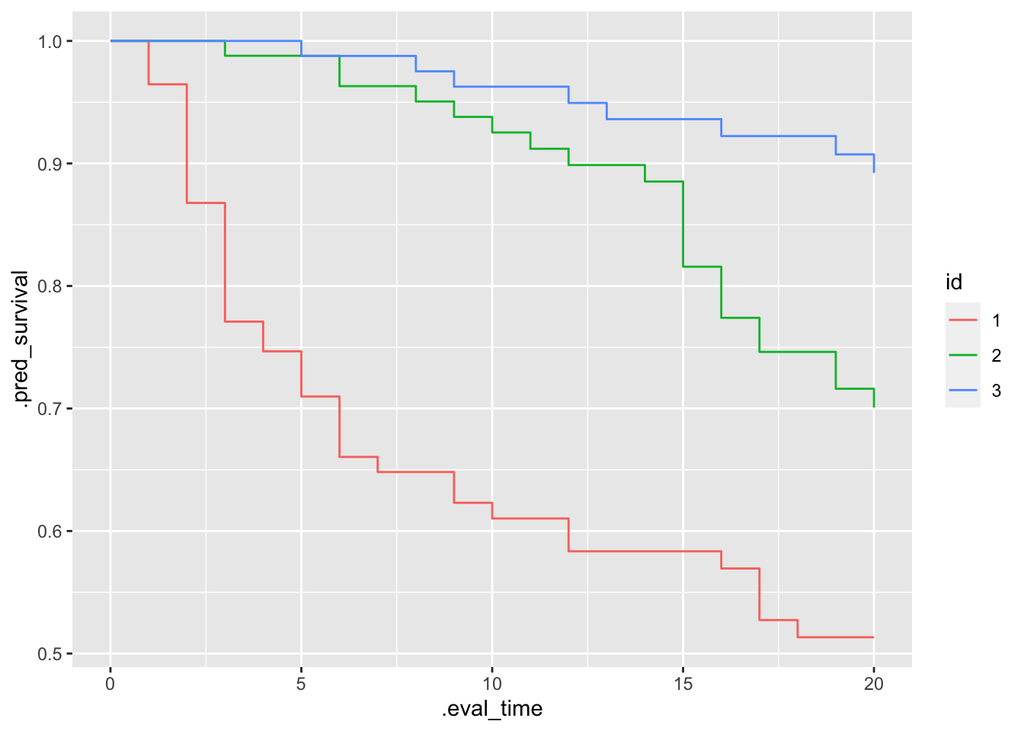

```r
f_pred <- f_pred %>%
  mutate(id = factor(1:3)) %>%
  unnest(cols = .pred)

f_pred %>%
  ggplot(aes(x = .eval_time, y = .pred_survival, col = id)) +
  geom_step()
```

Notes on reference observations: * in the survival package, the observation $x$ is centered with the mean predictor before the weighted linear combination is calculated * in contrast, all engines in censored use a reference observation of 0

### Comparison of predictions between survival, censored, and linear predictor

```r
library(tidymodels)
library(ggplot2)
library(prodlim)
set.seed(43500)

# add 0.5 to X2 numeric predicor (with mean 0) to demonstrate the effect of centering
train_dat <- SimSurv(2000) %>% mutate(X2 = X2 + 0.5)
test_dat <- SimSurv(20) %>% mutate(X2 = X2 + 0.5)
test_pred <- test_dat[, 5:6]

head(train_dat)
```

```
##   eventtime  censtime     time event X1          X2 status
## 1  2.934438  8.307951 2.934438     1  1 0.335223388      1
## 2  5.139809  9.952870 5.139809     1  1 0.004070846      1
## 3  4.020271  5.484262 4.020271     1  1 1.611825776      1
## 4  5.320128 16.902705 5.320128     1  1 1.189535607      1
## 5  7.821060  4.395734 4.395734     0  0 1.486007149      0
## 6  3.943778 10.226083 3.943778     1  0 0.099672223      1
```

```r
# compare value of linear predictor using the true coefficients of 1 with the predictions from the survival package
fit_survival <- coxph(Surv(time, status) ~ X1 + X2, data = train_dat)
pred_survival <- predict(fit_survival, newdata = test_pred)

pred <- bind_cols(
  test_pred %>% mutate(linear_pred = X1 * 1 + X2 * 1),
  tibble(pred_survival = pred_survival)
)
```

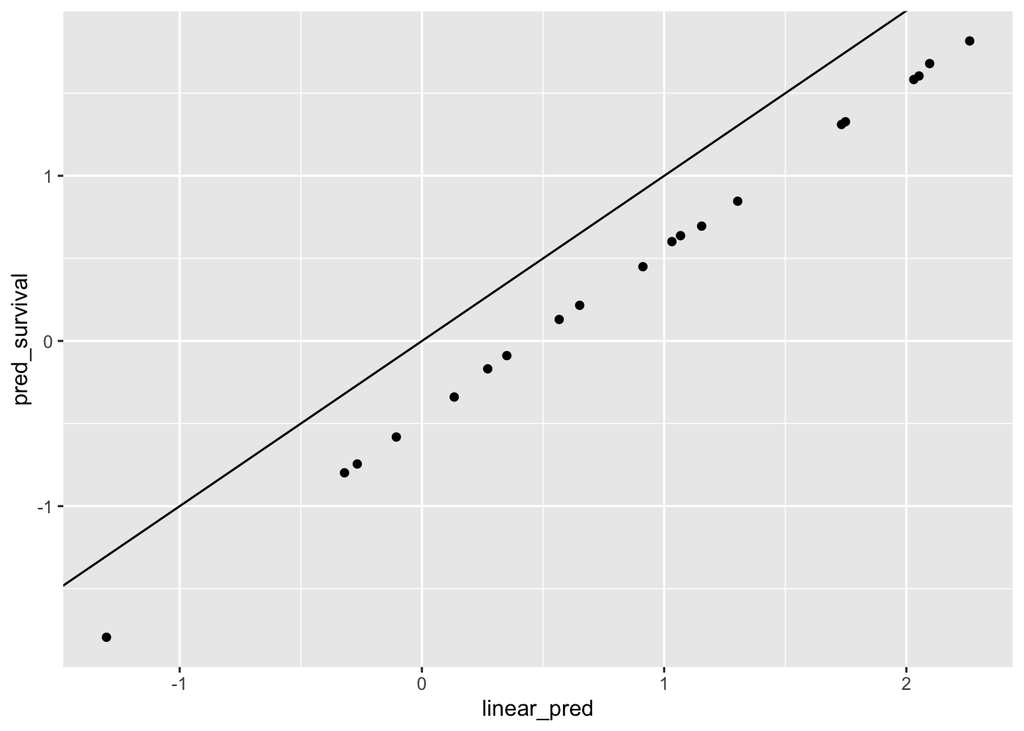

```r
# plot
pred %>%
  ggplot(aes(linear_pred, pred_survival)) +
  geom_point() +
  geom_abline(slope = 1, intercept = 0)
```

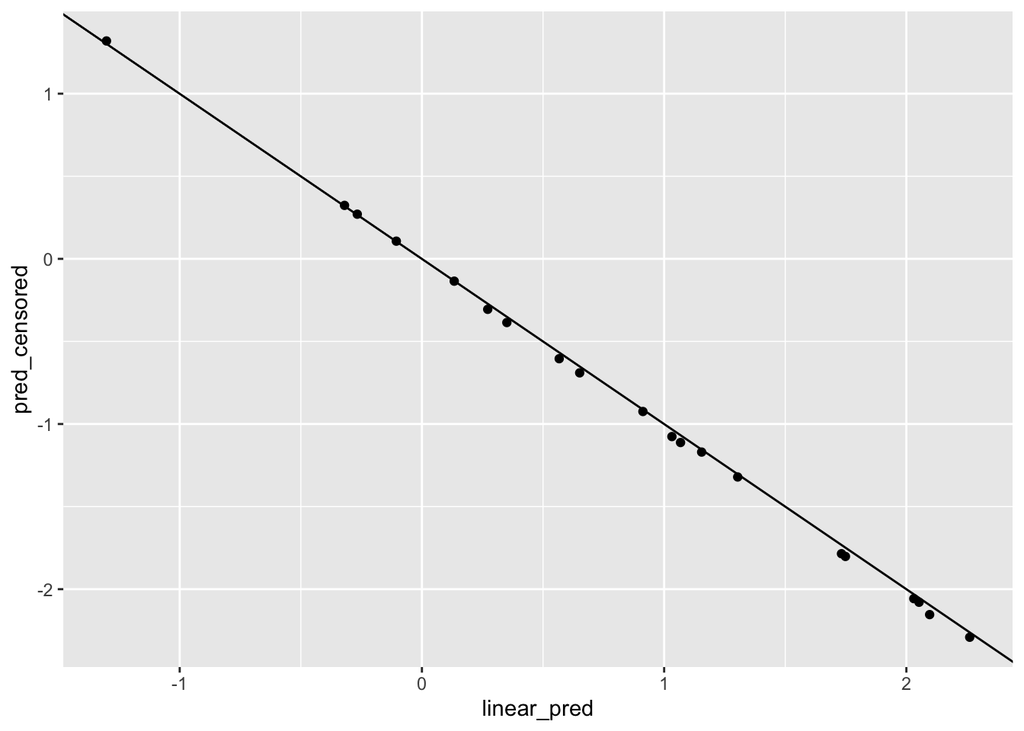

```r
# measuring performance
fit_censored <- proportional_hazards() %>%
  set_engine("survival") %>%
  fit(Surv(time, status) ~ X1 + X2, data = train_dat)
pred_censored <- predict(fit_censored, type = "linear_pred", new_data = test_pred)

pred <- bind_cols(
  pred,
  pred_censored %>% rename(pred_censored = .pred_linear_pred)
)

pred %>%
  ggplot(aes(linear_pred, pred_censored)) +
  geom_point() +
  geom_abline(slope = -1, intercept = 0)
```

### Model and prediction types available in censored

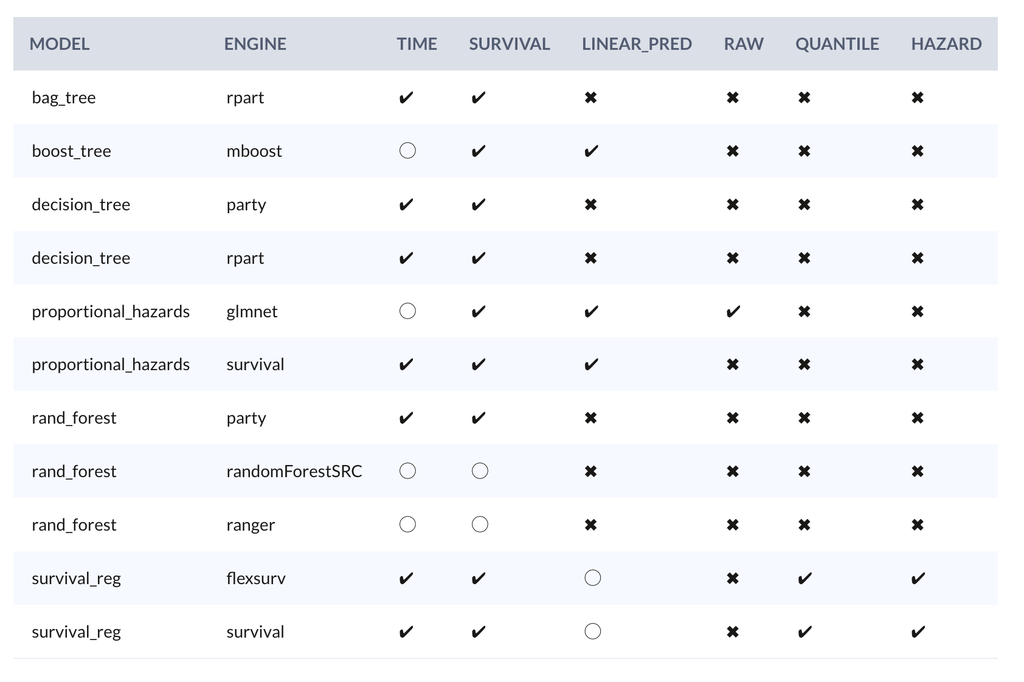

# Central lessons from week 2

- Learned to use various types of mixed models in `parsnip` workflow to produce predictions
- Learned framework of `lme4` model
- Learned to use `censored` package as means to generate survival curves from `parsnip` workflow